# SQLite Data Base Notebook

### (1) Tek Tablo Sorguları:

#### WHERE, LIKE

[output not shown]

MS Access’te “%” işareti yerine “*” ve “_” işareti yerine “?” kullanılır.

```sql
SELECT Uzun_Adı, üretici_id FROM ArabaUretici
WHERE Uzun_Adı LIKE "a%";
```

```sql
SELECT üretici_adı FROM ArabaUretici WHERE üretici_adı LIKE "a%b";
```

#### AND, NOT ve OR

1. Silindir sayısı 6 ve motor hacmi 150 cc’ye eşit veya küçük olan arabların verisini listeleyen sorguyu yazınız.

```sql
SELECT * FROM araba_verisi WHERE silindir_sayisi=6 AND motor_haci <= 150;
```

2. Motor hacmi 350 cc’den büyük olan arabalardan, silindir sayısı 6’dan küçük eşit olan, veya tüketim değeri 20 mpg’den küçük olan arabaların verisini bulunuz.

```sql
SELECT * FROM araba_verisi WHERE motor_hacmi>350 AND (silindir_sayısı <= 6 OR tuketim < 20);
```

#### IN

IN işleci, bir alanda bulunan birden çok değeri içeren kayıtları seçmek amacıyla kullanılır. Çoklu OR bağlacı gibi.

1. “ArabaAdı” tablosuna kayıtlı arabalardan, marka_id’si 3,14 veya 23 olan arabaların model ve marka_id bilgilerini listeleyen bir sorgu yazınız.

```sql
SELECT marka_id, model FROM ArabAdı WHERE marka_id IN (3,14,23);
```

2. Aynı sorgunun eş değeri OR kullanarak;

```sql
SELECT marka_id, model FROM ArabAdı WHERE marka_id=3 OR marka_id=14 OR marka_id=23;
```

#### BETWEEN

Bir aralık belirtmek için kullanılır.

1. Beygir gücü 150 ile 200 arasında olan arabaların verisini listeleyiniz.

```sql
SELECT * FROM araba_verisi WHERE beygir_gücü BETWEEN 150 AND 200;
```

#### DISTINCT

Farklı değer alan kayıtları listemelek amacıyla kullanılır. Tekrar eden (Aynı olan) kayıtlardan (satırlardan) bir tanesini gösterir.

1. Araba verisi kayıtlarından farklı olan silindir sayılarını listeleyin.

```sql
SELECT DISTINCT silindir_sayısı FROM araba_verisi;
```

2. Araba verisi kayıtlarından silindir sayısı ve motor hacmi farklı olan kayıtları listeleyin.

```sql
SELECT DISTINCT silindir_sayısı, motor hacmi FROM araba_verisi;
```

#### Aritemetik İşlemler:

SELECT sorgularında aritmetik işlemler (toplama, çıkarma, çarpma, bölme işlemleri) kullanılabilir.

1. Araba verisi kayıtlarında bulunan arabaların silindir sayıları, ağırlıkları ve 100kg başına beygir güçlerini listeleyen bir sorgu yazınız.

```sql
SELECT silindir_sayısı, ağırlığı, (beygir_gücü/ağırlığı)*100 FROM araba_verisi;
```

$\underline{NOT}$: Aritmetik ifadeler WHERE ölçütünde de kullanılabilir:

```sql
SELECT beygir_gücü, ağırlığı,(beygir_gücü/ağırlığı)*100) FROM araba_verisi WHERE ((beygir_gücü/ağırlığı)*100) >4.5;
```

#### Fonksiyonlar:

| Fonksiyon | İşlevi |
| --- | --- |
| `MAX()` | En büyük değeri listeler |
| `MIN()` | En küçük değeri listeler |
| `AVG()` | Ortalama değeri listeler |
| `SUM()` | Toplam değeri listeler |
| `COUNT(*)` | Sorgudaki kayıt (liste) sayısını listeler |

$\underline{Örnekler}$:

1. Motor hacmi en büyük olan arabanın motor hacmi nedir?

```sql
SELECT MAX(motor_hacmi) FROM araba_verisi;
```

2. Ortalama motor hacmi nedir?

```sql
SELECT AVG(motor_hacmi) FROM araba_verisi;
```

3. Model yılı 1978 olan arabaların en küçük ve en büyük motor hacimleri ile ortalama motor hacmini uygun başlıklar ile listeleyiniz.

```sql
SELECT MAX(motor_hacmi) AS [Maximum cc], MIN(motor_hacmi) AS [Minimum cc], AVG(motor_hacmi) AS [Ortalama hacim] FROM araba_verisi WHERE model_yılı=1978;
```

$\underline{NOT}$: “AS” işlecini kendisinden önceki değişken veya işleme bir isim vermek için kullanıyoruz. Ayrıca eğer vereceğimiz isimde “boşluk” veya “özel ifade ( ) ? ! vs.” varsa köşeli parantez [ ] kullanıyoruz.

4. Araba verisine kayıtlı kaç tane 6 silindirli araba vardır?

```sql
SELECT COUNT(*) FROM araba_verisi WHERE silindir_sayısı=6;
```

#### ORDER BY

SQL cümlesi ile elde edilen satırlar kümesini sıralamak amacıyla kullanılır. Artan, ASC veya azalan, DESC.

1. Araba üreticilerinin listesini adına göre sıralanmış olarak veren bir sorgu yazınız.

```sql
SELECT * FROM ArabaÜretici ORDER BY Uzun_Adı;
```

```sql
SELECT * FROM Kıta ORDER BY kıta_adı DESC;
```

3. Araba verisi tablosunda kayıtlı olan arabalardan 8 silindirli olanları beygir gücüne göre küçükten büyüğe sıralayın. Beygir gücü aynı olan arabalar hızlanma değerine göre artan sırada sıralansın.

```sql
SELECT silindir_sayısı, beygir_gücü, hızlanma FROM araba_verisi WHERE silindir_sayısı=8 ORDER BY beygir_gücü ASC hızlanma;
```

### (2) Gruplama & Tablo Birleştirme:

#### GROUP BY

Gruplanacak ya da sınıflanacak sorgularda kullanılır. WHERE kelimesinden sonra yazılır. Yoksa FROM kelimesinden sonra gelir.

1. Araba verisi tablosunda silindir sayısına göre kaçar tane araba vardır?

```sql
SELECT silindir_sayısı, COUNT(*) AS [Araba sayısı] FROM araba_verisi GROUP BY silindir_sayısı;
```

2. Her model yılı için silindir sayılarına göre kaçar tane araba vardır?

```sql
SELECT model_yılı, silindir_sayısı, COUNT(*) AS [Araba sayısı] FROM araba_verisi GROUP BY model_yılı, silindir_sayısı;
```

3. Her model yılı için 6 ve 8 silindirli arabaların ortalama motor hacmi nedir?

```sql
SELECT silindir_sayısı, model_yılı, AVG(motor_hacmi) AS [Ortalama Hacim] FROM araba_verisi
WHERE silindir_sayısı IN (6,8) GROUP BY model_yılı, silindir_sayısı;
```

#### HAVING

Gruplama sorgularında fonksiyon içeren GROUP BY deyimi ile birlikte kullanılır. Fonksiyonun değeri ile ilgili ölçütler HAVING ile yazılır.

1. Araba verisi tablosunda silindir sayısına göre, 20 taneden fazla olan araba sayılarını listeleyiniz.

```sql
SELECT silindir_sayısı , COUNT(*) AS [Araba Sayısı] FROM araba_verisi
GROUP BY silindir_sayısı HAVING COUNT(*)>20;
```

2. Araba verisi tablosunda silindir sayısına göre, 20 taneden fazla olan araba sayılarını, araba sayılarına göre sıralı olacak biçimde listeleyiniz.

```sql
SELECT silindir_sayısı, COUNT(*) AS [Araba Sayısı] From araba_verisi
GROUP BY silindir_sayısı HAVING COUNT(*) > 20
ORDER BY COUNT(*);
```

3. Model yılı 1972 ile 1977 arasında olan arabaların en küçük hızlanma değerlerini, her yıl için 12 saniyeden daha hızlı olanı listeleyin. Acaba 1972 ile 1977 arasında 12 saniyeden daha hızlı arabaların üretildiği yıllar hangileriydi? Hızlanma değeri sırasında listeleyin.

```sql
SELECT model_yılı, MIN(hızlanma), araba_id FROM araba_verisi
WHERE model_yılı BETWEEN 1972 AND 1977
GROUP BY hızlanma HAVING MIN(hızlanma) < 12;
```

#### INNER JOIN

İki farklı tabloyu birleştirebilmek için kesişim noktaları olması lazım ki bu kesişim noktası ise ya “primary key” ya da “foreign key” olması gerekir.

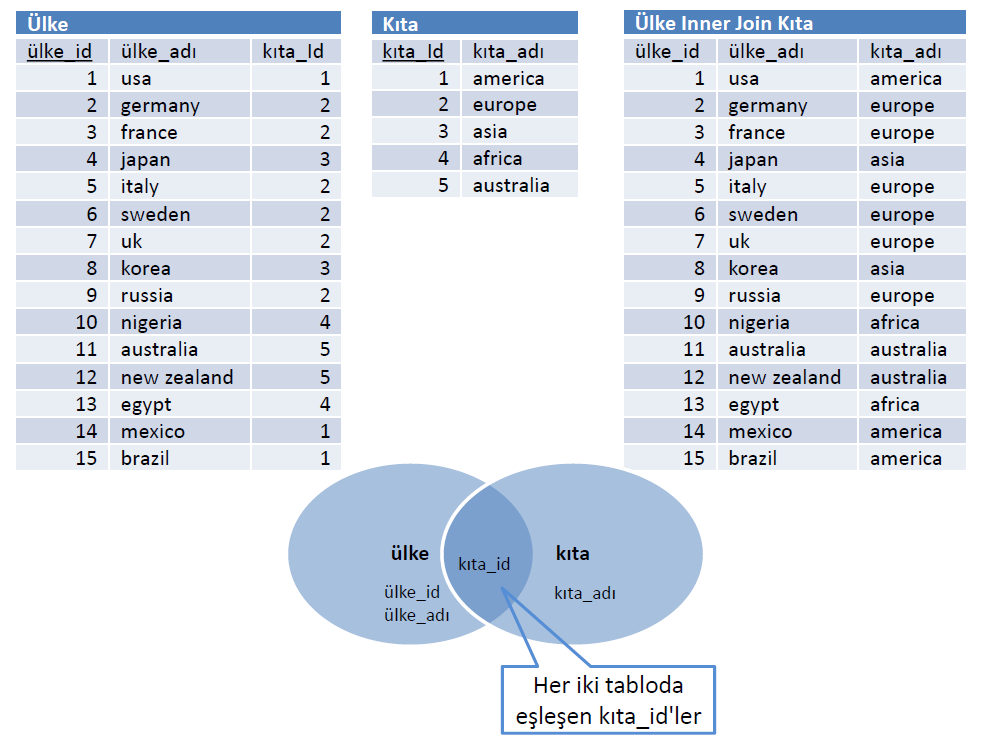

1. Araba veritabanında bulunan ülke ve kıta tablolarından yararlanarak ülke id , ülke adı ve kıta adı bilgilerini listeleyen bir sorgu yazınız.

```sql
SELECT ülke_id, ülke_adı, kıta_adı
FROM Ülke INNER JOIN Kıta ON Ülke.kıta_id = Kıta.kıta_id;
```

$\underline{NOT}:$ kıta_id alan adı her iki tabloda aynı olduğu için tablo adlarını belirtmek gerekir. Hangi tablonun önce yazıldığının önemi yoktur. Her iki tablonun eşleşen kayıtları (satırları) seçilir.

2. Araba veritabanına kayıtlı arabaların, araba id , modeli, silindir sayısı ve motor hacmi bilgilerini listeleyen bir sorgu yazınız.

```sql
SELECT araba_id, model, silindir_sayısı, motor_hacmi
FROM ArabaAdı INNER JOIN araba_verisi ON ArabaAdı.id = araba_verisi.araba_id;
```

3. Araba veritabanına kayıtlı arabaların, araba id , markası, modeli, silindir sayısı ve motor hacmi bilgilerini listeleyen bir sorgu yazınız.

Araba id silindir sayısı ve motor hacmi bilgileri araba verisi tablosundadır. Araba modeli bilgisi araba adı tablosundadır. Marka bilgisi ise araba üreticisi tablosundadır. İstenen bilgiler bu üç tablonun birleştirilmesi ile elde edilir. SQL’de tablolar ikişerli birleştirildiği için üç tabloyu ikişerli ilişkilendirmek gerekir.

```sql
SELECT araba_verisi.araba_Id, Marka, ArabaAdı.Model, silindir_sayısı, motor_hacmi
FROM (araba_verisi INNER JOIN ArabaAdı ON araba_verisi.araba_Id = ArabaAdı.Id)
INNER JOIN MarkaÜretici ON MarkaÜretici.marka_Id = ArabaAdı.marka_id;
```

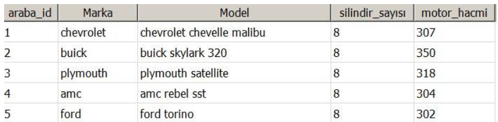

4. Her ülkede kaçar tane araba üreticisi firma vardır?

```sql
SELECT ülke_adı, COUNT(*) AS [Üretici Sayısı]
FROM Ülke INNER JOIN ArabaÜretici ON Ülke.ülke_id = ArabaÜretici.ülke_kodu
GROUP BY ülke_adı;
```

#### Outter Join (LEFT JOIN & RIGHT JOIN)

İki tablodan bir tanesindeki tüm kayıtlar ile diğer tablodan eşleşen kayıtların seçildiği sorgu tipidir. SELECT cümlesinde ilk yazılan tablo soldaki tablodur.

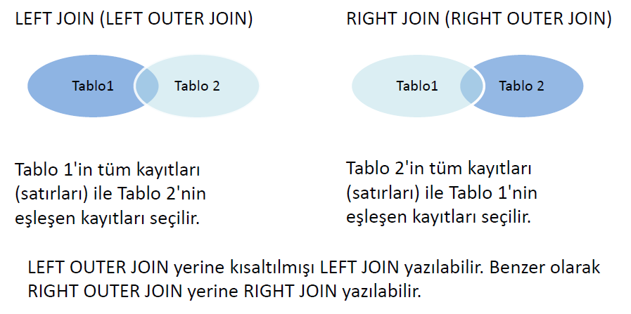

1. Araba veritabanında bulunan araba üreticilerin tüm satırlarına ait üretici id , üretici adı, uzun adı ve ülke adları biçimde listeleyen bir sorgu yazınız.

```sql
SELECT üretici_id , üretici_adı , Uzun_adı , ülke_adı
FROM ArabaÜretici LEFT JOIN Ülke ON ArabaÜretici.ülke_kodu=Ülke.ülke_id;
```

2. Araba üreticilerinin hepsinin id’si ve adı ile birlikte, her birinin ürettiği marka sayısını listeleyen bir sorgu yazınız.

```sql
SELECT ArabaÜretici.üretici_id , üretici_adı, COUNT(*) AS [Marka Sayısı]
FROM ArabaÜretici LEFT JOIN MarkaÜretici ON ArabaÜretici.üretici_id = MarkaÜretici.üretici_Id
GROUP BY ArabaÜretici.üretici_id , üretici_adı;
```

#### –ÇALIŞMA SORULARI (Fatura.db)–

**İlişkisel Şema:**

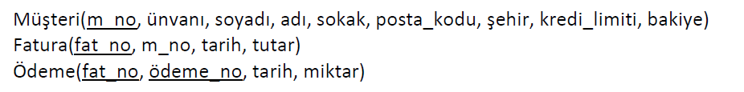

1. Hangi müşterilere fatura kesilmiş? Müşteri no, adı, soyadı (tekrarsız)

```sql
SELECT Müşteri.m_no, adı, soyadı, COUNT(*) AS [Kesilen Fatura Sayısı]
FROM Müşteri INNER JOIN Fatura ON Müşteri.m_no = Fatura.m_no
GROUP BY adı, soyadı;
```

2. Kesilen tüm faturaların toplam tutarı nedir?

```sql
SELECT SUM(tutar) AS [Kesilen Tüm Faturaların Tutarı]
From Fatura;
```

3. Tutarı en büyük faturanın toplam tutarı kaç TL’dir?

```sql
SELECT MAX(tutar) AS [Kesilen En Büyük Fatura Tutarı]
From Fatura;
```

4. Tutarı en büyük faturanın toplam tutarı kaç TL’dir ve müşterisi kimdir? Adı ve soyadı.

```sql
SELECT MAX(tutar) AS [Kesilen Fatura Tutarı] , adı, soyadı
From Fatura INNER JOIN Müşteri ON Fatura.m_no = Müşteri.m_no;
```

5. Hiç ödeme yapılmamış faturalar; Fatura no ve tarih.

```sql
SELECT Fatura.fat_no, Fatura.tarih
FROM Fatura LEFT JOIN Ödeme ON Fatura.fat_no = Ödeme.fat_no
WHERE ödeme_no IS NULL;
```

6. Hiç ödeme yapılmamış faturalar; Fatura no, tarih, müşteri adı ve soyadı.

```sql
SELECT Fatura.fat_no, Fatura.tarih, adı, soyadı
FROM (Fatura LEFT JOIN Ödeme ON Fatura.fat_no = Ödeme.fat_no)
INNER JOIN Müşteri ON Müşteri.m_no = Fatura.m_no
WHERE ödeme_no IS NULL;
```

7. Fatura kesilen her Müşteri için; Müşteri adı, soyadı ve en büyük olan fatura tutarı.

```sql
SELECT adı, soyadı, MAX(tutar)
FROM Fatura müşteri ON Fatura.m_no=müşteri.m_no
GROUP BY adı, soyadı;
```

8. Faturalara yapılan ödemeler; Fatura no, fatura tarihi, fatura tutarı, ödeme no, ödeme tarihi ve ödeme tutarı.

```sql
SELECT Fatura.fat_no, Fatura.tarih AS [Fatura Tarihi], tutar, ödeme_no, Ödeme.tarih AS [Ödenme Tarihi], miktar
FROM Fatura LEFT JOIN Ödeme ON Fatura.fat_no = Ödeme.fat_no
WHERE ödeme_no IS NOT NULL;
```

9. Faturalara yapılan ödemelerin fatura bazında toplamları; Fatura numarası ve ödeme toplamı.

```sql
SELECT fat_no, SUM(miktar)
FROM Ödeme
GROUP BY fat_no;
```

10. Kesilen tüm faturalar ve ödenmeyeler de görünecek biçimde yapılan ödemeler.

```sql
SELECT Fatura.fat_no, tutar, miktar, (tutar-miktar) AS Kalan
FROM Fatura LEFT JOIN Ödeme ON Fatura.fat_no = Ödeme.fat_no
GROUP BY Fatura.fat_no;
```

11. Londra’daki müşterilere kesilen faturalar; fatura numarası, müşteri numarası, müşteri adı, soyadı ve fatura tutarı.

```sql
SELECT fat_no, Fatura.m_no, adı, soyadı, şehir,     tutar
FROM Fatura INNER JOIN Müşteri ON Fatura.m_no = Müşteri.m_no
WHERE şehir = "London";
```

12. Şehirlere göre fatura toplamları.

```sql
SELECT şehir, SUM(tutar) AS [Toplam Tutar]
FROM Fatura INNER JOIN Müşteri ON Fatura.m_no=Müşteri.m_no
GROUP BY şehir;
```

13. Londra şehrine ait faturaların toplamı.

```sql
SELECT şehir, SUM(tutar) as [Toplam Tutar]
FROM Fatura INNER JOIN Müşteri ON Fatura.m_no = Müşteri.m_no
WHERE şehir = "London"
```

14. Fatura toplamı 500’den büyük olan şehirler.

```sql
SELECT şehir, SUM(tutar)
FROM Fatura INNER JOIN Müşteri ON Fatura.m_no=Müşteri.m_no
GROUP BY şehir HAVING SUM(tutar)>500;
```

#### –ÇALIŞMA SORULARI (Market.accdb)–

**İlişkisel Şema:**

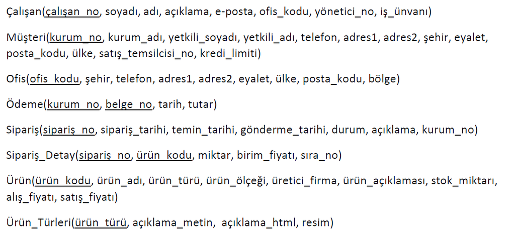

1. Japonya’dan verilen siparişlerin tarihi, durumu, ülkesi ve müşteri adını listeleyin.

```sql
SELECT ülke, kurum_adı, Müşteri.kurum_no, sipariş_tarihi, durum
FROM Sipariş INNER JOIN Müşteri ON Sipariş.kurum_no = Müşteri.kurum_no
WHERE ülke = "Japan";
```

2. Siparişi olan müşterilerin numarası ve adını listeleyin.

```sql
SELECT Müşteri.kurum_no, kurum_adı, COUNT(*) AS [Sipariş Sayısı]
FROM Müşteri INNER JOIN Sipariş ON Müşteri.kurum_no = Sipariş.kurum_no
GROUP BY Müşteri.kurum_no, kurum_adı;
```

3. Siparişi olmayan müşterilerin numarası, adını ve ülkesini listeleyin.

```sql
SELECT Müşteri.kurum_no, kurum_adı, ülke
FROM Müşteri LEFT JOIN Sipariş ON Müşteri.kurum_no = Sipariş.kurum_no
WHERE sipariş_no IS NULL;
```

4. Satış temsilcisi olmayan müşterilerin adını, şehrini, eyaletini ve ülkesini listeleyin.

```sql
SELECT kurum_adı, ülke, şehir, eyalet
FROM Müşteri WHERE satış_temsilcisi_no IS NULL;
```

5. Ödemesi olan müşterilerin numarası, adı, şehri ve ülkesini listeleyin.

```sql
SELECT Müşteri.kurum_no, kurum_adı, ülke, şehir
FROM Müşteri INNER JOIN Ödeme ON Müşteri.kurum_no = Ödeme.kurum_no;
```

6. Satış temsilcisi olan fakat siparişi olmayan müşterilerin numarası, adı ve satış temsilcisin numarasını listeleyin.

```sql
SELECT Müşteri.kurum_no, Müşteri.kurum_adı, Müşteri.satış_temsilcisi_no
FROM Müşteri
WHERE Müşteri.satış_temsilcisi_no IS NOT NULL
AND Müşteri.kurum_no NOT IN(SELECT kurum_no FROM Sipariş);
```

7. Önceki sorguya satış temsilcisinin adını ve soyadını ekleyiniz.

```sql
SELECT Müşteri.kurum_no, Müşteri.kurum_adı, Müşteri.satış_temsilcisi_no, Çalışan.adı, Çalışan.soyadı
FROM Müşteri, Çalışan
WHERE Müşteri.satış_temsilcisi_no = Çalışan.çalışan_no
AND MÜşteri.kurum_no NOT IN (SELECT kurum_no FROM Sipariş);
```

8. En az bir müşteriye atanmış çalışanların numarası, adı, soyadı ve baktıkları müşteri sayısını listeleyin.

```sql
SELECT DISTINCT çalışan_no, adı, soyadı, COUNT(*) AS [Baktıkları Müşteri Sayısı]
FROM Müşteri INNER JOIN Çalışan ON Müşteri.satış_temsilcisi_no = Çalışan.çalışan_no
GROUP BY çalışan_no, adı, soyadı;
```

9. Müşteri sayısı en çok olan çalışanın müşteri sayısını bulun.

```sql
SELECT MAX([müşteri sayısı])
FROM ( SELECT çalışan_no, adı, soyadı, count(*) AS [müşteri sayısı]
FROM Çalışan, Müşteri
WHERE Çalışan.çalışan_no=Müşteri.satış_temsilcisi_no
GROUP BY çalışan_no, adı, soyadı);
```

10. Numarası 10105 olan siparişte yer alan ürünlerin ürün kodu, miktarı ve birim fiyatını, sıra numarasına göre sıralı olacak biçimde listeleyin.

```sql
SELECT Sipariş.sipariş_no,ürün_kodu, miktar, birim_fiyatı, sıra_no
FROM Sipariş INNER JOIN Sipariş_Detay ON Sipariş.sipariş_no = Sipariş_Detay.sipariş_no
WHERE Sipariş.sipariş_no = 10105
ORDER BY sıra_no;
```

11. Numarası 10105 olan siparişin toplam tutarı ne kadardır?

```sql
SELECT Sipariş.sipariş_no, SUM(birim_fiyatı) AS [Sipariş Tutarı]
FROM Sipariş, Sipariş_Detay
WHERE Sipariş.sipariş_no = Sipariş_Detay.sipariş_no AND Sipariş.sipariş_no = 10105
GROUP BY Sipariş.sipariş_no;
```

12. Her siparişin sipariş tarihini, durumunu ve siparişin toplam tutarını listeleyin.

```sql
SELECT Sipariş.sipariş_no, sipariş_tarihi, durum, SUM(miktar*birim_fiyatı) AS [Toplam Tutar]
FROM Sipariş INNER JOIN Sipariş_Detay ON Sipariş.sipariş_no = Sipariş_Detay.sipariş_no
GROUP BY Sipariş.sipariş_no, sipariş_tarihi, durum;
```

13. Önceki sorgunun listesine müşteri adını ve ülkesini ekleyiniz.

```sql
SELECT Sipariş.sipariş_no, sipariş_tarihi, durum, kurum_adı, ülke, SUM(miktar*birim_fiyatı) AS [Toplam Tutar]
FROM (Sipariş INNER JOIN Sipariş_Detay ON Sipariş.sipariş_no = Sipariş_Detay.sipariş_no)
INNER JOIN Müşteri ON Sipariş.kurum_no = Müşteri.kurum_no
GROUP BY Sipariş.sipariş_no, sipariş_tarihi, durum, kurum_adı, ülke;
```